# Project 1- Reproducible Research Week 2

Claudia Delgado

February 23, 2018

## Loading and preprocessing the data

The data is organized in the csv file named is activity. Always verify that the file is in the working directory. The following is the portion of the code for reading and processing the data.

```r
    getwd()
```

```
## [1] "C:/Users/Claudia/Desktop/Coursera/Reproducible Research/Week 2"
```

```r
    stepdata <- read.csv("activity.csv", header=TRUE)
    colnames(stepdata)= c("steps", "date", "interval")
    summary(stepdata)
```

```
##      steps                date          interval
##  Min.   :  0.00   2012-10-01:  288   Min.   :   0.0
##  1st Qu.:  0.00   2012-10-02:  288   1st Qu.: 588.8
##  Median :  0.00   2012-10-03:  288   Median :1177.5
##  Mean   : 37.38   2012-10-04:  288   Mean   :1177.5
##  3rd Qu.: 12.00   2012-10-05:  288   3rd Qu.:1766.2
##  Max.   :806.00   2012-10-06:  288   Max.   :2355.0
##  NA's   :2304     (Other)   :15840
```

```r
    stepdata$day <- weekdays(as.Date(stepdata$date))
    stepdata$DateTime<- as.POSIXct(stepdata$date, format="%Y-%m-%d")
    activity_no<- stepdata[!is.na(stepdata$steps),]
```

## Calculate the mean steps and plot a histogram

This portion of the code ignores missing values. Calculate the total number of steps taken per day. Calculate and report the mean and median of the total number of steps taken per day.

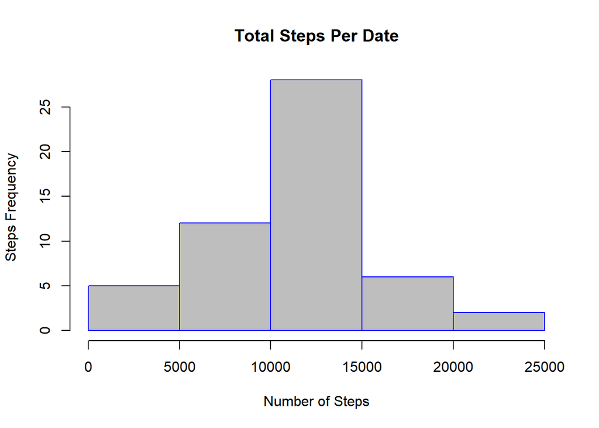

```r
stepsbydate <- aggregate(stepdata$steps~stepdata$date, FUN=sum,)
    colnames(stepsbydate)<- c("Date", "Steps")
    # Histogram of the total number of steps taken each day
    Figure1 <- hist(stepsbydate$Steps, ylab="Steps Frequency ", xlab="Number of Steps", main = "Total Steps Per Date", border="blue",
         col="grey", breaks=5)
```

```r
    summary(stepsbydate)
```

```
##          Date        Steps
##  2012-10-02: 1   Min.   :   41
##  2012-10-03: 1   1st Qu.: 8841
##  2012-10-04: 1   Median :10765
##  2012-10-05: 1   Mean   :10766
##  2012-10-06: 1   3rd Qu.:13294
##  2012-10-07: 1   Max.   :21194
##  (Other)   :47
```

The mean and median were obtained by the functio summary or by the calcukation of each one separately as inicated in the R code. Th average number of steps taken each day was 10766 steps while the median number of steps taken each day was 10765 steps.

## What is the average daily activity pattern?

Make a time series plot (i.e. type = “l”) of the 5-minute interval (x-axis) and the average number of steps taken, averaged across all days (y-axis) Which 5-minute interval, on average across all the days in the dataset, contains the maximum number of steps?

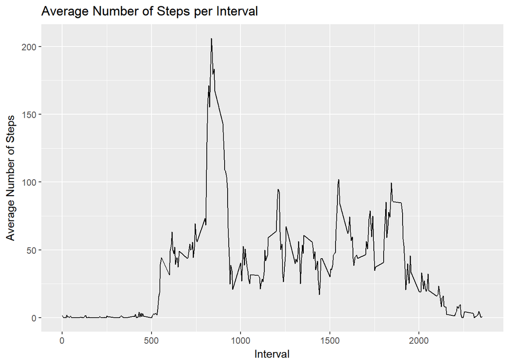

```r
    library(ggplot2)
    library(plyr)
    activity_no<- stepdata[!is.na(stepdata$steps),]
    intervals <- ddply(activity_no, .(interval), summarize, Avg = mean(steps))

    ##Create line plot of average number of steps per interval
    Figure2 <- ggplot(intervals, aes(x=interval, y=Avg), xlab = "Interval", ylab="Average Number of Steps")
    Figure2 + geom_line() + xlab("Interval")+ylab("Average Number of Steps")+ ggtitle("Average Number of Steps per Interval")
```

```r
    summary(intervals)
```

```
##     interval           Avg
##  Min.   :   0.0   Min.   :  0.000
##  1st Qu.: 588.8   1st Qu.:  2.486
##  Median :1177.5   Median : 34.113
##  Mean   :1177.5   Mean   : 37.383
##  3rd Qu.:1766.2   3rd Qu.: 52.835
##  Max.   :2355.0   Max.   :206.170
```

```r
    Max_Steps <- max(intervals$Avg)
    intervals[intervals$Avg==Max_Steps,1]
```

```
## [1] 835
```

The 5-minute interval, on average across all the days in the dataset that contains the maximum number of steps is at the 835 interval.

## Imputing missing values

```r
sum(is.na(stepdata$steps))
```

```
## [1] 2304
```

```r
    replacedata <- which(is.na(stepdata$steps))
    l <-length(replacedata)
    meansteps <-with(stepdata,tapply(steps,date,mean,na.rm=TRUE))
    nomissing <-mean(meansteps,na.rm = TRUE)
    for (i in 1:l) {
        stepdata[replacedata[i],1]<- nomissing
    }
    summary(replacedata)
```

```
##    Min. 1st Qu.  Median    Mean 3rd Qu.    Max.
##       1    7273   10660    9324   12020   17570
```

```r
    sum(is.na(replacedata))
```

```
## [1] 0
```

```r
    sum(is.na(stepdata))
```

```
## [1] 0
```

```r
    head(replacedata)
```

```
## [1] 1 2 3 4 5 6
```

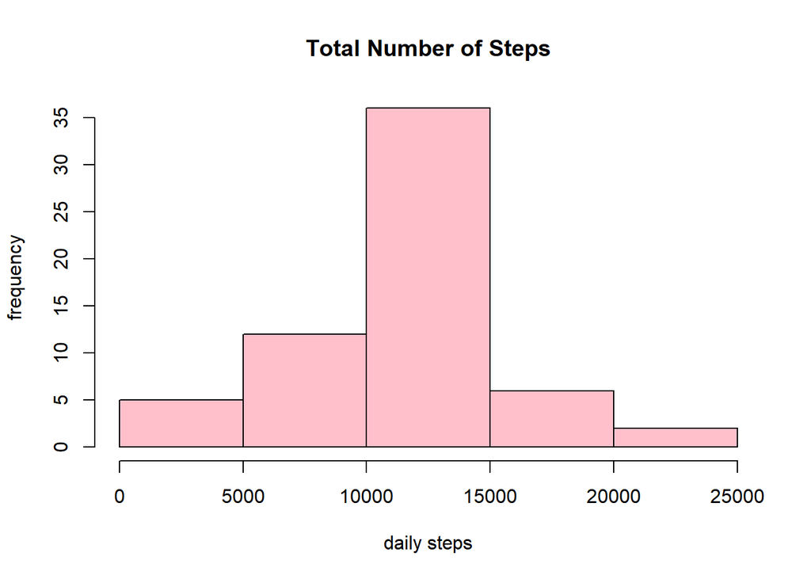

```r
    steps<-with(stepdata,tapply(steps,date,sum,na.rm=TRUE))
    hist(steps, col="pink", breaks=5, xlab="daily steps", ylab="frequency",
         main="Total Number of Steps")
```

```r
    summary(steps)
```

```
##    Min. 1st Qu.  Median    Mean 3rd Qu.    Max.
##      41    9819   10770   10770   12810   21190
```

The total number of missing data (NA) was 2304.

## Are there differences in activity patterns between weekdays and weekends?

For this part the weekdays() function may be of some help here. Use the dataset with the filled-in missing values for this part.

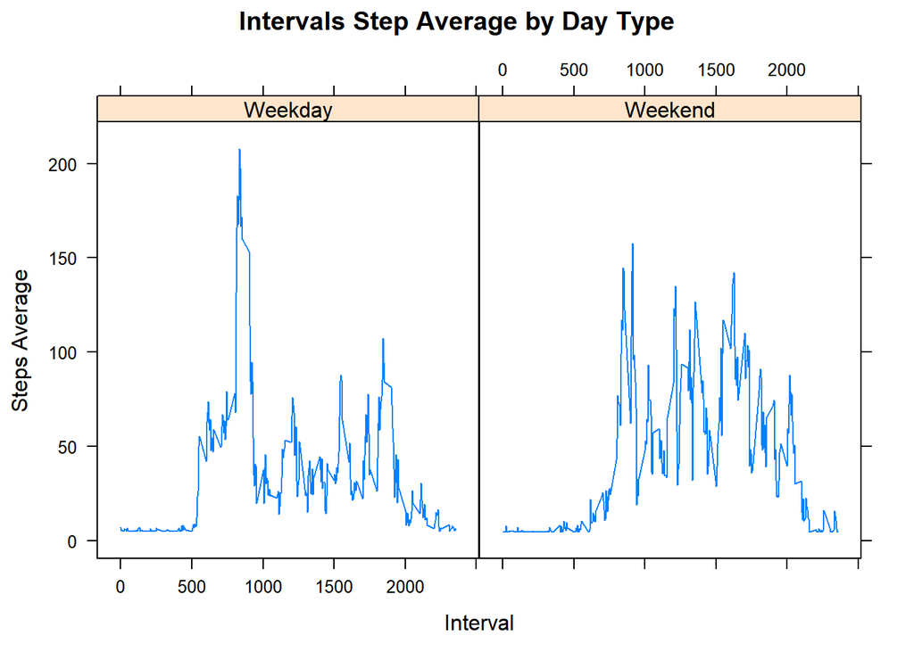

```r
library(plyr)
    library (ggplot2)
    library (lattice)
    stepdata$DayCategory <- ifelse(stepdata$day %in% c("Saturday", "Sunday"), "Weekend", "Weekday")
    weekday <- ddply(stepdata, .(interval, DayCategory), summarize, Avg = mean(steps))
    xyplot(Avg~interval|DayCategory, data=weekday, type="l",  layout = c(2,1),
           main="Intervals Step Average by Day Type",
           ylab="Steps Average", xlab="Interval")
```

Yes there are differences in the intervals between weekdays and weekends